# Curso CISC

Introdução à Análise de Dados de Clima e Saúde

Autor

Curso de Análise de Dados de Clima e Saúde

Data de Publicação

01/07/2026

# 1 Introdução

## 1.1 O que é análise de dados de clima e saúde?

A análise de dados de clima e saúde é um campo interdisciplinar que combina conhecimentos de meteorologia, epidemiologia, estatística e ciência de dados para entender como as condições climáticas afetam a saúde humana. Essa análise envolve a coleta, processamento e interpretação de dados relacionados ao clima (como temperatura, umidade, precipitação) e à saúde (como incidência de doenças, hospitalizações, mortalidade) para identificar padrões, tendências e relações causais.

## 1.2 Por que é importante analisar dados de clima e saúde?

A análise de dados de clima e saúde é crucial para: - **Prevenção de doenças**: Identificar como as condições climáticas influenciam a propagação de doenças, como doenças respiratórias, doenças transmitidas por vetores e doenças relacionadas ao calor. - **Planejamento de políticas públicas**: Informar políticas de saúde pública e estratégias de mitigação para proteger a população contra os impactos negativos do clima. - **Adaptação às mudanças climáticas**: Compreender como as mudanças climáticas podem afetar a saúde humana no futuro e desenvolver estratégias de adaptação. - **Resposta a emergências**: Preparar sistemas de saúde para responder a eventos climáticos extremos, como ondas de calor, tempestades e inundações.

## 1.3 Quais são os principais desafios na análise de dados de clima e saúde?

- **obtençcão de dados climaticos**: A obtenção de dados climáticos de qualidade e resoluções temporais e espaciais pode ser difícil, especialmente em regiões com infraestrutura limitada para monitoramento climático. Alternativamente podemos usar dados obtidos de aeroportos (REDEMET) ou dados de satelites.
- **Qualidade dos dados de saúde**: Alem dos sistemas tradicionais como SIM,AIH , etc… A existencia de dados de assistenciais pode não existir ou ser inconsistente, incompleta ou imprecisa, o que pode dificultar bastante as análises.
- **Complexidade das relações**: As relações entre clima e saúde são complexas e podem ser influenciadas por muitos fatores, como comportamento humano, condições socioeconômicas e acesso a serviços de saúde.
- **Modelagem estatística**: Desenvolver modelos estatísticos que capturem adequadamente as relações entre clima e saúde pode ser desafiador, especialmente quando há muitos fatores de confusão.
- **Interdisciplinaridade**: A análise de dados de clima e saúde requer colaboração entre especialistas de diferentes áreas, o que pode ser difícil de coordenar.

## 1.4 Ciênca de dados e análise de dados de clima e saúde

A ciência de dados desempenha um papel fundamental na análise do impacto ambiental na saúde pública, fornecendo ferramentas essenciais para processar e interpretar grandes volumes de informações. Por meio de métodos estatísticos avançados, aprendizado de máquina e técnicas de visualização, essa disciplina permite identificar padrões e relações complexas entre variáveis climáticas e epidemiológicas. Além disso, a abordagem facilita a integração de diferentes fontes — como registros meteorológicos, dados de saúde e indicadores socioeconômicos —, proporcionando uma compreensão muito mais completa dessas interações.

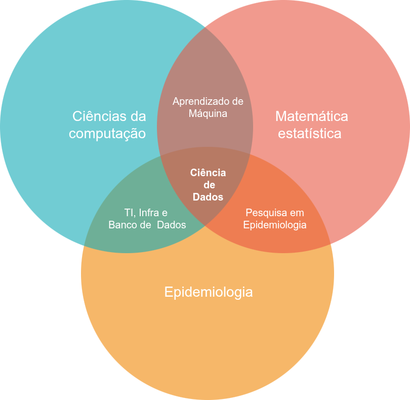

## 1.5 Conclusão

A análise de dados de clima e saúde é um campo vital para entender e mitigar os impactos do clima na saúde humana. Com a crescente preocupação com as mudanças climáticas, a análise de dados de clima e saúde se torna cada vez mais importante para informar políticas públicas, planejar respostas a emergências e proteger a saúde da população. Apesar dos desafios, avanços na coleta de dados, modelagem estatística e colaboração interdisciplinar estão ajudando a superar essas dificuldades e a melhorar nossa compreensão das complexas relações entre clima e saúde.